# Embedding Qualitative and Quantitative Methods for Policy Evaluation (ICHPS 2025 Workshop): R Demo

Eli Ben-Michael

In this brief R demo, we will use Difference in Differences (DiD) and the Synthetic Control Method (SCM) for a stylized case study evaluating the impact of Right to Carry Laws on Violent Crime, following *Right-to-Carry Laws and Violent Crime: A Comprehensive Assessment Using Panel Data and a State-Level Synthetic Control Analysis* (2017) by John J. Donohue, Abhay Aneja, and Kyle D. Weber (available online [here](https://onlinelibrary.wiley.com/doi/full/10.1111/jels.12219)). We will use a reduced version of the dataset:

```r
library(tidyverse)
rtc_panel <- read_csv("https://ebenmichael.github.io/assets/code/rtc_panel.csv")
```

The `rtc_panel` dataset contains the following variables:

- `fips`: State FIPS code
- `stusps`: State abbreviation
- `year`: Year
- `RTC`: Year that Right to Carry Law was enacted (infinity if never enacted)
- `violent_rate`: Violent crime rate per 100,000

## Difference in Differences using the `did` package

To estimate the effect using differences in differences with the [`did` package](https://bcallaway11.github.io/did/), we first use the `att_gt` function to estimate the “group-time” average treatment effects that correspond to the 2x2 DiD estimate for each treatment time cohort at each event time. The `att_gt` function takes in the outcome variable (`violent_rate`), the time variable (`year`), the unit variable (`fips`), the treatment variable (`RTC`), and the dataset (`rtc_panel`). (Note that the `did` package requires the unit variable to be numeric, like the fips code). There is also an additional option for setting the “base period”. Choosing `base_period = "universal"` will set the base period to be the first period preceding treatment for each treatment-time cohort. This is how DiD estimates are usually reported, but the default is `base_period = "variable"`, which sets the base period to be the immediately preceding period. [Here’s a longer discussion about these two choices.](https://bcallaway11.github.io/posts/event-study-universal-v-varying-base-period)

```r
library(did)
did_gt <- att_gt("violent_rate", "year", "fips", "RTC",
                 data = rtc_panel,
                 base_period = "universal")
```

We can then use the `aggte` function to aggregate the effects and the `ggdid` function to plot them. For instance, we can estimate the ATT across event times and plot the results:

```r
dynamic_effects <- aggte(did_gt, type = "dynamic")
dynamic_effects
```

```
##
## Call:
## aggte(MP = did_gt, type = "dynamic")
##
## Reference: Callaway, Brantly and Pedro H.C. Sant'Anna.  "Difference-in-Differences with Multiple Time Periods." Journal of Econometrics, Vol. 225, No. 2, pp. 200-230, 2021. <https://doi.org/10.1016/j.jeconom.2020.12.001>, <https://arxiv.org/abs/1803.09015>
##
##
## Overall summary of ATT's based on event-study/dynamic aggregation:
##       ATT    Std. Error     [ 95%  Conf. Int.]
##  110.6341       61.4493    -9.8043    231.0726
##
##
## Dynamic Effects:
##  Event time  Estimate Std. Error [95% Simult.  Conf. Band]
##         -37  105.3104    63.0344      -61.4677    272.0886
##         -36  113.5941    58.6744      -41.6482    268.8363
##         -35  118.4728    67.2342      -59.4173    296.3629
##         -34  -91.3345   122.9539     -416.6493    233.9803
##         -33 -120.4423   121.8629     -442.8703    201.9857
##         -32 -140.7078   129.7619     -484.0351    202.6196
##         -31 -162.7163   138.0197     -527.8925    202.4600
##         -30 -153.9433   112.1725     -450.7322    142.8456
##         -29 -167.8528    89.1481     -403.7233     68.0177
##         -28 -146.0240   105.5458     -425.2799    133.2318
##         -27 -115.0682    91.1402     -356.2094    126.0731
##         -26 -104.0672    85.6207     -330.6046    122.4702
##         -25 -108.3694    78.5029     -316.0745     99.3357
##         -24  -94.2017    87.9473     -326.8949    138.4915
##         -23 -103.5069    85.8359     -330.6137    123.5999
##         -22 -112.2479    79.6504     -322.9891     98.4933
##         -21 -118.2910    86.6415     -347.5294    110.9474
##         -20 -110.6664    84.3430     -333.8233    112.4906
##         -19 -113.5881    66.8787     -290.5375     63.3612
##         -18  -83.9368    53.0146     -224.2042     56.3306
##         -17  -72.9038    46.6644     -196.3697     50.5622
##         -16  -90.0053    49.5295     -221.0518     41.0411
##         -15 -106.1990    50.5708     -240.0007     27.6026
##         -14  -84.5428    46.3322     -207.1297     38.0441
##         -13  -49.6734    39.7648     -154.8841     55.5373
##         -12  -41.9055    33.2076     -129.7671     45.9561
```

[output cut: 31 more lines]

```
##          20  170.9679    96.6353      -84.7122    426.6480
##          21  175.9863   106.3567     -105.4150    457.3877
##          22  181.8122   103.4490      -91.8960    455.5203
##          23  194.4066   100.4358      -71.3290    460.1422
##          24  168.3268    95.2447      -83.6743    420.3278
##          25  160.4866   132.2870     -189.5219    510.4950
##          26  117.7078   177.9970     -353.2413    588.6569
##          27  140.7333   173.8922     -319.3551    600.8218
##          28  316.1989    97.2005       59.0232    573.3745 *
##          29  333.9844    92.2557       89.8919    578.0768 *
## ---
## Signif. codes: `*' confidence band does not cover 0
##
## Control Group:  Never Treated,  Anticipation Periods:  0
## Estimation Method:  Doubly Robust
```

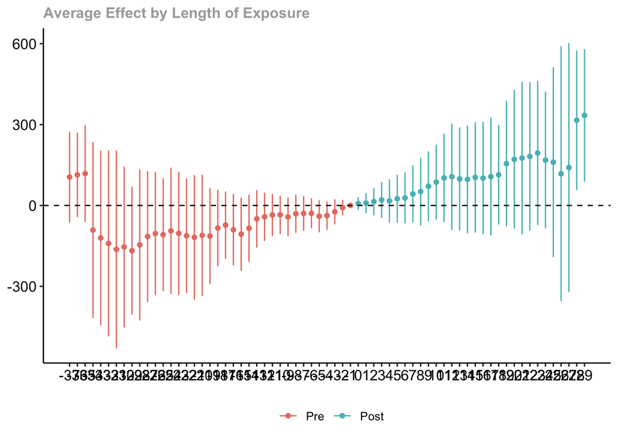

```r
ggdid(dynamic_effects)
```

## Synthetic Controls with Staggered Adoption using the `augsynth` package

Now we can use the [`augsynth` package](https://github.com/ebenmichael/augsynth) to estimate the effect. To do this, we use the ``multisynth` function. This function needs the treatment variable to be an indicator, so we can define a new variable `rtc` which is equal to 1 if RTC is currently enacted in the year (i.e. `year >= RTC`) and 0 otherwise. We can then estimate effects by defining the outcome and treatment variables as the left and right hand sides of an equation, `violent_rate ~ rtc`, respectively. We also need to specify the unit variable (`stusps`), the time variable (`year`), and the dataset (`rtc_panel`). We can also specify `fixedeff = T` to include fixed effects and `time_cohort = T` to aggregate to the time-cohort level when fitting the synthetic control weights. Finally, we can specify the number of leads (`n_leads`) to include in the analysis, which is the number of periods after the initial treatment period for which we want to estimate effects.

```r
rtc_panel <- rtc_panel %>%
  mutate(rtc = ifelse(year >= RTC, 1, 0))

library(augsynth)
fe_ascm <- multisynth(
              violent_rate ~ rtc, stusps, year,
              rtc_panel, fixedeff = T, time_cohort = T, n_leads = 11)
```

We can then use the `summary` function to report the ATT estimates along with confidence intervals:

```r
fe_ascm_summ <- summary(fe_ascm)
fe_ascm_summ
```

```
##
## Call:
## multisynth(form = violent_rate ~ rtc, unit = stusps, time = year,
##     data = rtc_panel, n_leads = 11, fixedeff = T, time_cohort = T)
##
## Average ATT Estimate (Std. Error): 25.485  (42.844)
##
## Global L2 Imbalance: 8.120
## Scaled Global L2 Imbalance: 0.049
## Percent improvement from uniform global weights: 95.1
##
## Individual L2 Imbalance: 76.800
## Scaled Individual L2 Imbalance: 0.158
## Percent improvement from uniform individual weights: 84.2
##
##  Time Since Treatment   Level  Estimate Std.Error lower_bound upper_bound
##                     0 Average 15.046516  32.66643   -44.23925    81.15388
##                     1 Average  5.814935  36.88648   -58.49601    81.43983
##                     2 Average 10.216679  39.22125   -56.00555    90.13640
##                     3 Average 19.465837  41.78658   -50.06514   105.77084
##                     4 Average 13.217443  40.85973   -54.23392    97.68726
##                     5 Average 23.953310  39.17384   -41.29902   104.40867
##                     6 Average 21.576615  42.50792   -49.76541   110.33772
##                     7 Average 29.743117  46.95288   -45.08877   128.60331
##                     8 Average 37.319898  51.22182   -48.60595   142.15950
##                     9 Average 50.525898  57.76714   -44.31048   162.82109
##                    10 Average 66.709053  60.20486   -33.18479   186.80444
```

We can also plot the effects (note that we can also use `plot(fe_ascm)`, but this will run the `summary` function first):

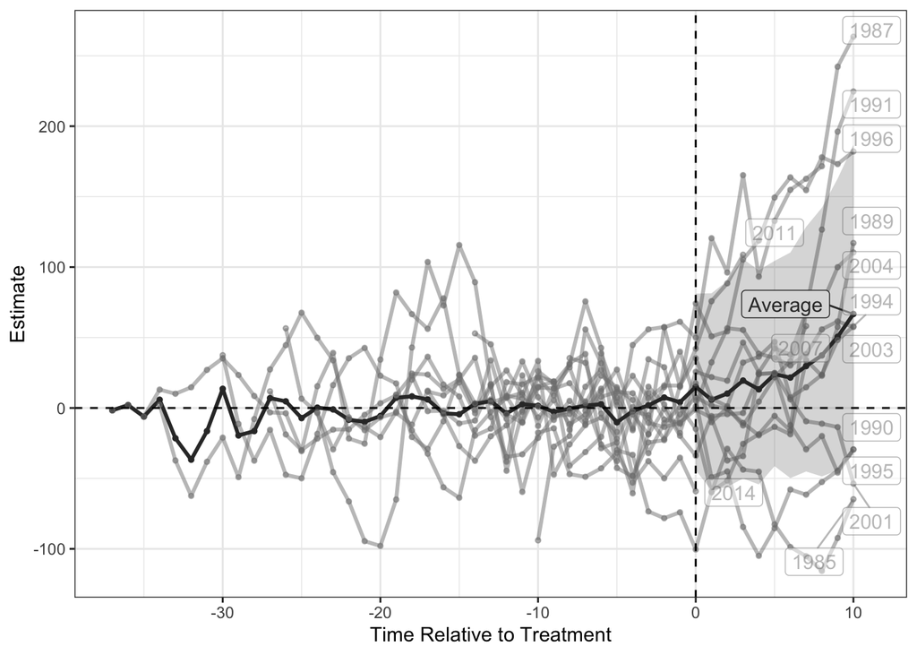

```r
plot(fe_ascm_summ)
```

To hone in on just the ATT estimates, we can use the plot function with the `levels` argument set to `"Average"`:

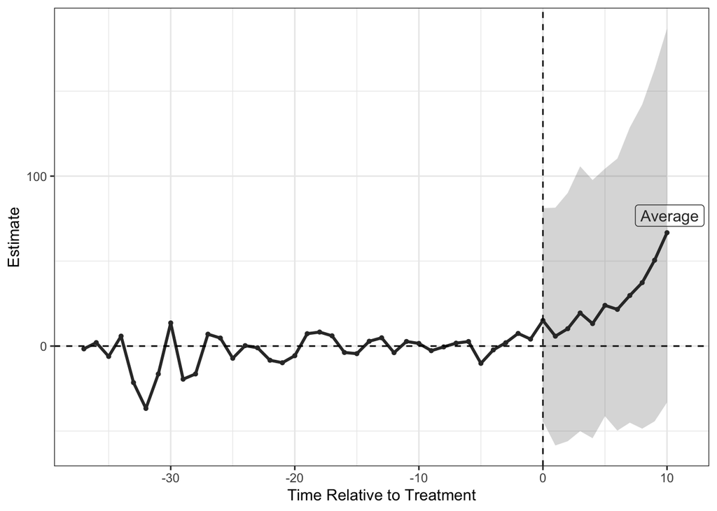

```r
plot(fe_ascm_summ, levels = "Average")
```